# S6_informe

## Limpieza de la base de datos

Para este proceso las consideraciones para la limpieza de la base de datos fueron:

- Información irrelevante para el estudio.
- Datos confusos.
- Tomar en cuenta que las respuestas de los encuestados vayan de acuerdo al tipo de variable que corresponda, finalmente podríamos decir que los datos ya se encuentra limpios ya que se pudo realizar un análisis sistemático en R el cual funcionó correctamente sin ningún problema de datos errados.

```r
# Carga de Librerias
library(readr)
library(dplyr)
library(stringr)
library(car)
P1<- read.csv("BaseDatos.csv", header=T, sep=',')
```

```r
names(P1)
```

```
##  [1] "Edad..aÃ.os.cumplidos."
##  [2] "GÃ.nero"
##  [3] "Carrera"
##  [4] "Ciclo"
##  [5] "Lugar.de.residencia"
##  [6] "Â.QuÃ..mÃ.todo.de.estudio.usas.con.mÃ.s.frecuencia."
##  [7] "Â.De.quÃ..manera.prefiere.realizar.sus.apuntes.para.un.examen."
##  [8] "Â.Que.zona.es.de.su.preferencia.para.aplicar.su.mÃ.todo.de.estudio."
##  [9] "Â.Eres.autodidacta."
## [10] "Â.Prefieres.estudiar.solo.o.con.un.grupo.de.amigos."
## [11] "DÃ.as.de.anticipaciÃ³n.que.tomas.para.rendir.un.examen"
## [12] "Â.CuÃ.ntos.dÃ.as.sueles.estudiar.a.la.semana..fuera.de.clases"
## [13] "Tiempo.que.le.dedica.a.estudiar.en.horas.al.dÃ.a...Ej..1.o.15..solo.el.nÃºmero.de.horas."
## [14] "Moda.de.notas.en.los.exÃ.menes.del.ciclo.regular.anterior..Ej..14.o.14.5..mÃ.ximo.1.decimal."
## [15] "Promedio.general.del.ciclo.regular.anterior..Ej..13.o.13.5..mÃ.ximo.1.decimal."
```

```r
P1 <- rename(P1, Edad = "Edad..aÃ.os.cumplidos." , Genero = "GÃ.nero" , Metodos = "Â.QuÃ..mÃ.todo.de.estudio.usas.con.mÃ.s.frecuencia.", Apuntes = "Â.De.quÃ..manera.prefiere.realizar.sus.apuntes.para.un.examen.", Zona = "Â.Que.zona.es.de.su.preferencia.para.aplicar.su.mÃ.todo.de.estudio.", Autodidacta = "Â.Eres.autodidacta.", Estudiar_solo_o_amigos = "Â.Prefieres.estudiar.solo.o.con.un.grupo.de.amigos." , Dias_de_anticipacion = "DÃ.as.de.anticipaciÃ³n.que.tomas.para.rendir.un.examen" , Dias_a_la_semana = "Â.CuÃ.ntos.dÃ.as.sueles.estudiar.a.la.semana..fuera.de.clases" , Tiempo = "Tiempo.que.le.dedica.a.estudiar.en.horas.al.dÃ.a...Ej..1.o.15..solo.el.nÃºmero.de.horas." , Moda = "Moda.de.notas.en.los.exÃ.menes.del.ciclo.regular.anterior..Ej..14.o.14.5..mÃ.ximo.1.decimal.", Promedio = "Promedio.general.del.ciclo.regular.anterior..Ej..13.o.13.5..mÃ.ximo.1.decimal.")
names(P1)
```

```
##  [1] "Edad"                   "Genero"                 "Carrera"
##  [4] "Ciclo"                  "Lugar.de.residencia"    "Metodos"
##  [7] "Apuntes"                "Zona"                   "Autodidacta"
## [10] "Estudiar_solo_o_amigos" "Dias_de_anticipacion"   "Dias_a_la_semana"
## [13] "Tiempo"                 "Moda"                   "Promedio"
```

```r
T1<-table(P1$Carrera)

P1 %>% mutate(Carrera =
        ifelse(Carrera == "AdministraciÃ³n y negocios digitales", "Administracion y negocios digitales",
        ifelse(Carrera == "BioingenierÃa", "Bioingenieria",
        ifelse(Carrera == "Ciencia de la computaciÃ³n", "Ciencia de la computacion",
        ifelse(Carrera == "Ing. de la energÃa", "Ing. de la energia",
        ifelse(Carrera == "Ing. ElectrÃ³nica", "Ing. Electronica",
        ifelse(Carrera == "Ing. de la energÃa", "Ing. de la energia",
        ifelse(Carrera == "Ing. MecÃ¡nica", "Ing. Mecanica",
        ifelse(Carrera == "Ing. MecatrÃ³nica", "Ing. Mecatronica",
        ifelse(Carrera == "Ing. QuÃmica", "Ing. Quimica",
        ifelse(Carrera == "Ing.Civil", "Ing. Civil", Carrera
        ))))))))))) -> P1

unique(P1$Carrera)
```

```
##  [1] "Ing. Electronica"                    "Ing. Civil"
##  [3] "Bioingenieria"                       "Ing. Industrial"
##  [5] "Ing. Ambiental"                      "Ing. de la energia"
##  [7] "Ing. Quimica"                        "Ing. Mecatronica"
##  [9] "Ciencia de la computacion"           "Administracion y negocios digitales"
## [11] "Ing. Mecanica"                       "Ciencia de datos"
```

```r
T2 <- table(P1$Lugar.de.residencia)

P1 %>% mutate(Lugar.de.residencia =
        ifelse(Lugar.de.residencia == "Balneareos del Sur (Pta. Hermosa, Pucusana, Pta. Negra, San Bartolo, Sta. MarÃa)", "Balneareos del Sur ta. Hermosa, Pta. Negra, San Bartolo, Sta. Maria)",
        ifelse(Lugar.de.residencia == "Central (Cercado, San Luis, BreÃ±a, La Victoria, RÃmac, Lince, San Miguel, JesÃºs MarÃa, Magdalena, Pblo. Libre)", "Central (Cercado, San Luis, Breña, La Victoria, Rímac, Lince, San Miguel, Jesús María, Magdalena, Pblo. Libre)",
        ifelse(Lugar.de.residencia == "Norte(AncÃ³n, Pte. Piedra, Sta. Rosa, Carabayllo, Comas, Los Olivos, Independencia, S.M. Porres)", "Norte(Ancón, Pte. Piedra, Sta. Rosa, Carabayllo, Comas, Los Olivos, Independencia, S.M. Porres)",Lugar.de.residencia
        )))) -> P1

unique(P1$Lugar.de.residencia)
```

```
## [1] "Central Sur (Barranco, Miraflores, Surco, San Borja, Surquillo, San Isidro, Chorrillos)"
## [2] "Este (S. J. de Lurigancho, Sta. Anita, Cieneguilla, Ate Vitarte, La Molina, Chaclacayo, Lurigancho, El Agustino)"
## [3] "Sur (S. J. de Miraflores, V.M. de Triunfo, Villa el Salvador, LurÃn y Pachacamac)"
## [4] "Norte(Ancón, Pte. Piedra, Sta. Rosa, Carabayllo, Comas, Los Olivos, Independencia, S.M. Porres)"
## [5] "Provincia"
## [6] "Balneareos del Sur ta. Hermosa, Pta. Negra, San Bartolo, Sta. Maria)"
## [7] "Central (Cercado, San Luis, Breña, La Victoria, Rímac, Lince, San Miguel, Jesús María, Magdalena, Pblo. Libre)"
```

```r
T3 <- table(P1$Metodos)

P1 %>% mutate(Metodos =
        ifelse(Metodos == "ResÃºmenes escritos", "Resumenes Escritos",
        ifelse(Metodos == "No tengo un mÃ©todo de estudios", "No tengo",
        ifelse(Metodos == "Active Recall : Explicar claramente un tema como si lo estuvieras enseÃ±ando a otra persona. Se repite el proceso hasta comprenderlo totalmente.", "Active Recall",
        ifelse(Metodos == "Escucha activa : escuchar activamente la clase y repasando Ãºnicamente en el salÃ³n, estar listo para el examen", "Escucha activa",
        ifelse(Metodos == "ResÃºmenes grÃ¡ficos (mapas mentales, diagramas)", "Resumenes Graficos", Metodos
        )))))) -> P1

unique(P1$Metodos)
```

```
## [1] "Resumenes Escritos" "Resaltado"          "Escucha activa"
## [4] "Resumenes Graficos" "Flashcards"         "Active Recall"
## [7] "No tengo"
```

```r
T4<-table(P1$Apuntes)

P1 %>% mutate(Apuntes =
        ifelse(Apuntes == "FÃsico", "Fisico",Apuntes
        )) -> P1
unique(P1$Apuntes)
```

```
## [1] "Fisico"  "Ambos"   "Virtual"
```

```r
T5<-table(P1$Zona)

P1 %>% mutate(Zona =
        ifelse(Zona == "CafeterÃa", "Cafeteria",Zona
        )) -> P1
unique(P1$Zona)
```

```
## [1] "Casa"       "Biblioteca" "Parque"     "Cafeteria"
```

##Determinamos lo casos efectivos

```r
TOTALDATOS=sum(!is.na(P1))+sum(is.na(P1))
TOTALDATOS
```

```
## [1] 3000
```

## Descriptores Númericos

Según el resultado nuestras 200 encuestas son correctas, dado que obtuvimos el 100% de datos completos.

## Determinamos si las variables tienen datos atípicos,con el fin de poder identificar a que varibles podemos calcular sus descriptores numéricos, ya que en las gráficas de caja, el simbolo * o ° identifica los valores atípicos. Estos valores atípicos son observaciones que están a por lo menos 1.5 veces el rango intercuartil (Q3 – Q1) del borde de la caja.

–> *Edad*

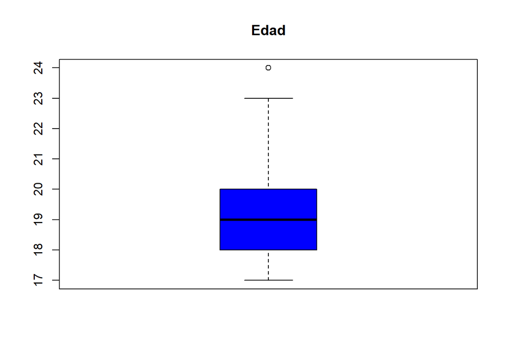

```r
 boxplot(P1$Edad,
        main = "Edad",
        boxwex = 0.5,col="blue")
```

A partir del resultado del boxplot, obtuvimos que 1 dato de la variable edad son atípicos es decir son muy diferentes significativamente en valor en relación a los demás datos, por lo que no es viable calcular el promedio.

*Descriptores de la variable edad:*

```r
cat('Mediana:',round(median(P1$Edad),2),'\n') #calcula la mediana de la edad
```

```
## Mediana: 19
```

```r
cat('Desviación Estándar:',round(sd(P1$Edad),2),'\n') #calcula la desviación estándar de la edad
```

```
## Desviación Estándar: 1.33
```

```r
cat('Rango:',round(range(P1$Edad),2),'\n') #calcula el rango de la edad
```

```
## Rango: 17 24
```

```r
cat('Rango Intercuartílico:',round(IQR(P1$Edad),2),'\n') #calcula el rango intercuartílico de la edad
```

```
## Rango Intercuartílico: 2
```

```r
cat('Coeficiente de Variación:', round((sd(P1$Edad)/mean(P1$Edad))*100,2),'\n')
```

```
## Coeficiente de Variación: 6.91
```

–> *Tiempo que le dedica a estudiar en horas al día*

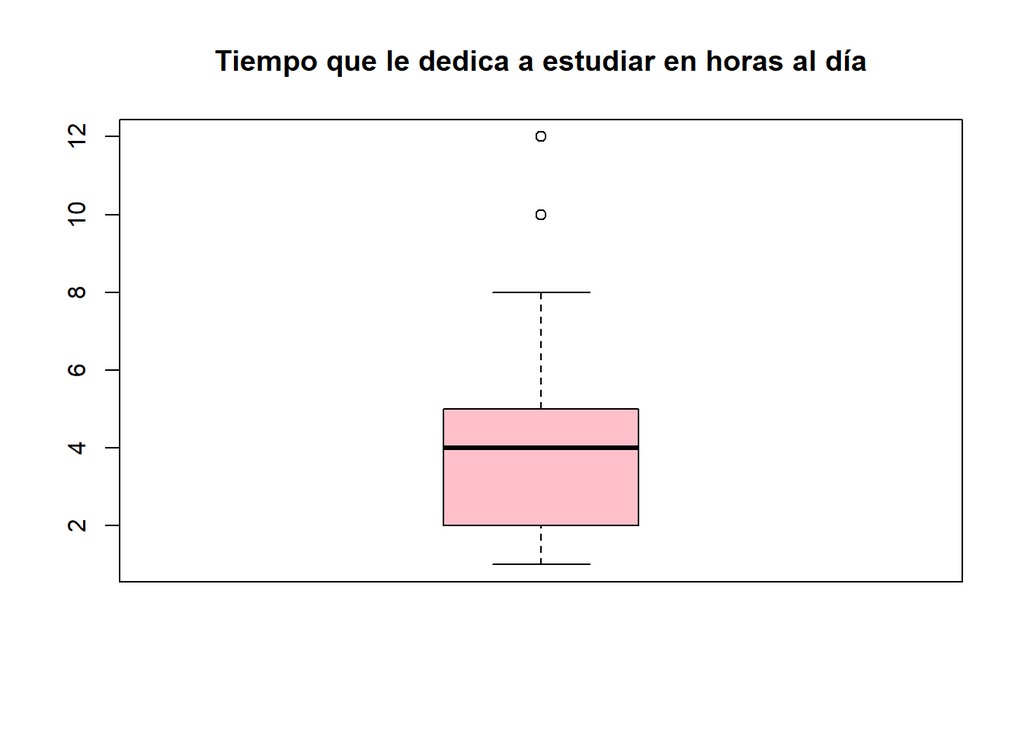

```r
 boxplot(P1$Tiempo,
        main = "Tiempo que le dedica a estudiar en horas al día",
        boxwex = 0.5,col="pink")
```

A partir del resultado del boxplot obtuvimos que 2 datos de la variable Tiempo son atípicos es decir son muy diferentes significativamente en valor en relación a los demás datos, por lo que no es viable calcular el promedio o media aritmética, más si calcular otros descriptores como mediana, desviación estándar, rango, rango intercuartílico y coeficiente de variación.

*Descriptores de la variable tiempo que le dedica a estudiar al día*

```r
cat('Mediana:',round(median(P1$Tiempo),2),'\n') #calcula la mediana de tiempo que le dedica a estudiar al día
```

```
## Mediana: 4
```

```r
cat('Desviación Estándar:',round(sd(P1$Tiempo),2),'\n') #calcula la desviación estándar de tiempo que le dedica a estudiar al día
```

```
## Desviación Estándar: 2.28
```

```r
cat('Rango:',round(range(P1$Tiempo),2),'\n') #calcula el rango de tiempo que le dedica a estudiar al día
```

```
## Rango: 1 12
```

```r
cat('Rango Intercuartílico:',round(IQR(P1$Tiempo),2),'\n') #calcula el rango intercuartílico de tiempo que le dedica a estudiar al día
```

```
## Rango Intercuartílico: 3
```

```r
cat('Coeficiente de Variación:', round((sd(P1$Tiempo)/mean(P1$Tiempo))*100,2),'\n')
```

```
## Coeficiente de Variación: 55.79
```

–> *Cantidad de días que estudia a la semana*

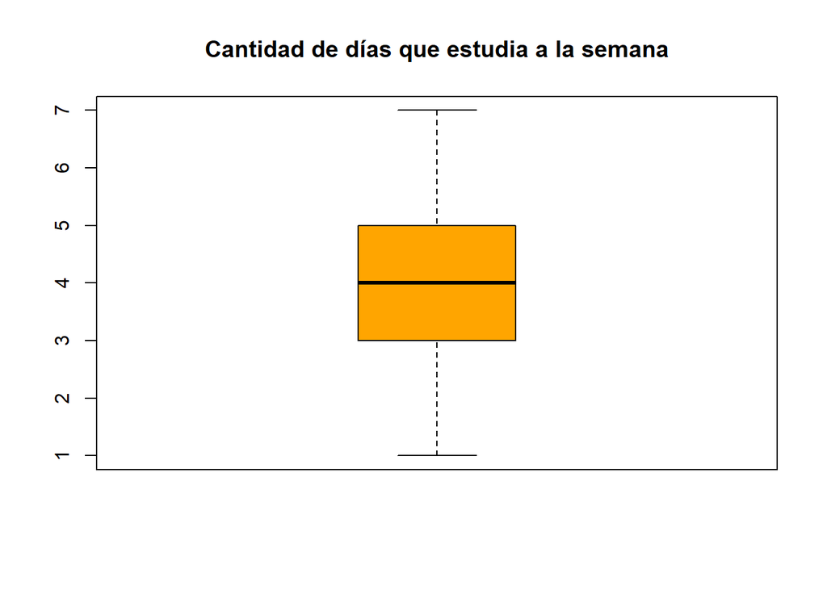

```r
 boxplot(P1$Dias_a_la_semana,
        main = "Cantidad de días que estudia a la semana",
        boxwex = 0.5,col="orange")
```

A partir del resultado del boxplot obtuvimos que 0 datos de la variable Dias_a_la_semana son atípicos es decir no existen diferencia entre los datos, por lo que es viable calcular el promedio o media aritmética, así mismo calcular otros descriptores como mediana, desviación estándar, rango, rango intercuartílico y coeficiente de variación.

*Descriptores de la variable cuantos dias estudia a la semana*

```r
cat('Media:',round(mean(P1$Dias_a_la_semana),2),'\n') #calcula el promedio de cuantos dias estudia a la semana
```

```
## Media: 4
```

```r
cat('Mediana:',round(median(P1$Dias_a_la_semana),2),'\n') #calcula la mediana de cuantos dias estudia a la semana
```

```
## Mediana: 4
```

```r
cat('Desviación Estándar:',round(sd(P1$Dias_a_la_semana),2),'\n') #calcula la desviación estándar de cuantos dias estudia a la semana
```

```
## Desviación Estándar: 1.7
```

```r
cat('Rango:',round(range(P1$Dias_a_la_semana),2),'\n') #calcula el rango de cuantos dias estudia a la semana
```

```
## Rango: 1 7
```

```r
cat('Rango Intercuartílico:',round(IQR(P1$Dias_a_la_semana),2),'\n') #calcula el rango intercuartílico de cuantos dias estudia a la semana
```

```
## Rango Intercuartílico: 2
```

```r
cat('Coeficiente de Variación:', round((sd(P1$Dias_a_la_semana)/mean(P1$Dias_a_la_semana))*100,2),'\n')
```

```
## Coeficiente de Variación: 42.47
```

–> *Días de anticipación para estudiar ante un examen*

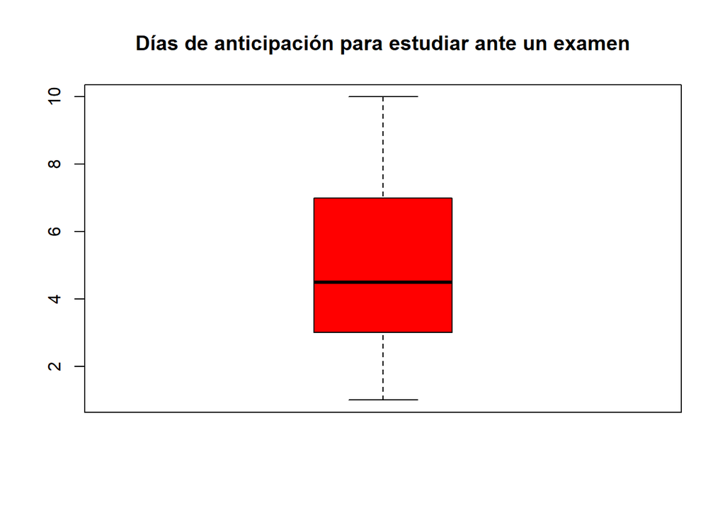

```r
 boxplot(P1$Dias_de_anticipacion,
        main = "Días de anticipación para estudiar ante un examen",
        boxwex = 0.5,col="red")
```

A partir del resultado del boxplot obtuvimos que 0 datos de la variable Dias_de_anticipacion son atípicos es decir no existen diferencia entre los datos, por lo que es viable calcular el promedio o media aritmética, asi mismo calcular otros descriptores como mediana, desviación estándar, rango, rango intercuartílico y coeficiente de variación.

*Descriptores de la variable Días de anticipación para rendir un examen:*

```r
cat('Media:',round(mean(P1$Dias_de_anticipacion),2),'\n') #calcula el promedio de Dias de anticipacion para rendir un examen
```

```
## Media: 5
```

```r
cat('Mediana:',round(median(P1$Dias_de_anticipacion),2),'\n') #calcula la mediana de Dias de anticipacion para rendir un examen
```

```
## Mediana: 4.5
```

```r
cat('Desviación Estándar:',round(sd(P1$Dias_de_anticipacion),2),'\n') #calcula la desviación estándar de Dias de anticipacion para rendir un examen
```

```
## Desviación Estándar: 2.51
```

```r
cat('Rango:',round(range(P1$Dias_de_anticipacion),2),'\n') #calcula el rango de Dias de anticipacion para rendir un examen
```

```
## Rango: 1 10
```

```r
cat('Rango Intercuartílico:',round(IQR(P1$Dias_de_anticipacion),2),'\n') #calcula el rango intercuartílico de Dias de anticipacion para rendir un examen
```

```
## Rango Intercuartílico: 4
```

```r
cat('Coeficiente de Variación:', round((sd(P1$Dias_de_anticipacion)/mean(P1$Dias_de_anticipacion))*100,2),'\n')
```

```
## Coeficiente de Variación: 50.1
```

–> *Promedio general del ciclo regular anterior*

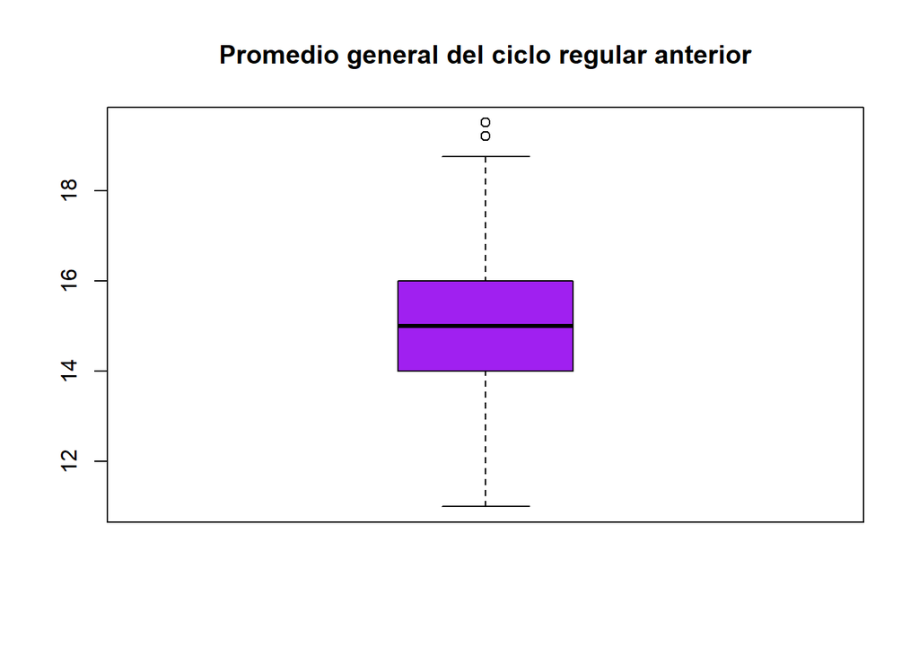

```r
 boxplot(P1$Promedio,
        main = "Promedio general del ciclo regular anterior",
        boxwex = 0.5,col="purple")
```

*Descriptores de la variable promedio general del ciclo regular anterior*

```r
cat('Mediana:',round(median(P1$Promedio),2),'\n') #calcula la mediana de
```

```
## Mediana: 15
```

```r
cat('Desviación Estándar:',round(sd(P1$Promedio),2),'\n') #calcula la desviación estándar de
```

```
## Desviación Estándar: 1.72
```

```r
cat('Rango:',round(range(P1$Promedio),2),'\n') #calcula el rango de
```

```
## Rango: 11 19.5
```

```r
cat('Rango Intercuartílico:',round(IQR(P1$Promedio),2),'\n') #calcula el rango intercuartílico de
```

```
## Rango Intercuartílico: 2
```

```r
cat('Coeficiente de Variación:', round((sd(P1$Promedio)/mean(P1$Promedio))*100,2),'\n')
```

```
## Coeficiente de Variación: 11.49
```

–> *Moda de notas en los exámenes del ciclo regular anterior*

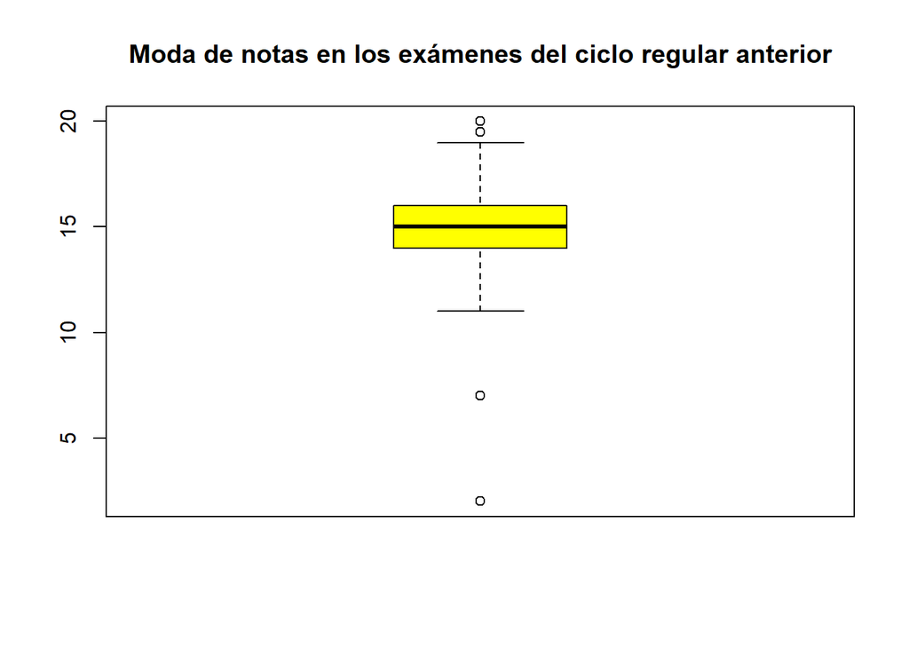

```r
 boxplot(P1$Moda,
        main = "Moda de notas en los exámenes del ciclo regular anterior",
        boxwex = 0.5,col="yellow")
```

A partir del resultado del boxplot obtuvimos que 4 datos de variable Moda son atípicos, 2 son un valor superior y los otros 2 son inferiores a diferencia de la gran mayoría de datos, por lo que no es viable calcular el promedio o media aritmética, pero si se podría calcular otros descriptores como mediana, desviación estándar, rango, rango intercuartílico y coeficiente de variación..

*Descriptores de la variable moda de notas en los exámenes del ciclo regular anterior*

```r
cat('Mediana:',round(median(P1$Moda),2),'\n') #calcula la mediana de notas en los exámenes del ciclo regular anterior
```

```
## Mediana: 15
```

```r
cat('Desviación Estándar:',round(sd(P1$Moda),2),'\n') #calcula la desviación estándar de notas en los exámenes del ciclo regular anterior
```

```
## Desviación Estándar: 2.01
```

```r
cat('Rango:',round(range(P1$Moda),2),'\n') #calcula el rango de notas en los exámenes del ciclo regular anterior
```

```
## Rango: 2 20
```

```r
cat('Rango Intercuartílico:',round(IQR(P1$Moda),2),'\n') #calcula el rango intercuartílico de notas en los exámenes del ciclo regular anterior
```

```
## Rango Intercuartílico: 2
```

```r
cat('Coeficiente de Variación:', round((sd(P1$Moda)/mean(P1$Moda))*100,2),'\n')
```

```
## Coeficiente de Variación: 13.37
```

## Descriptores Gráficos

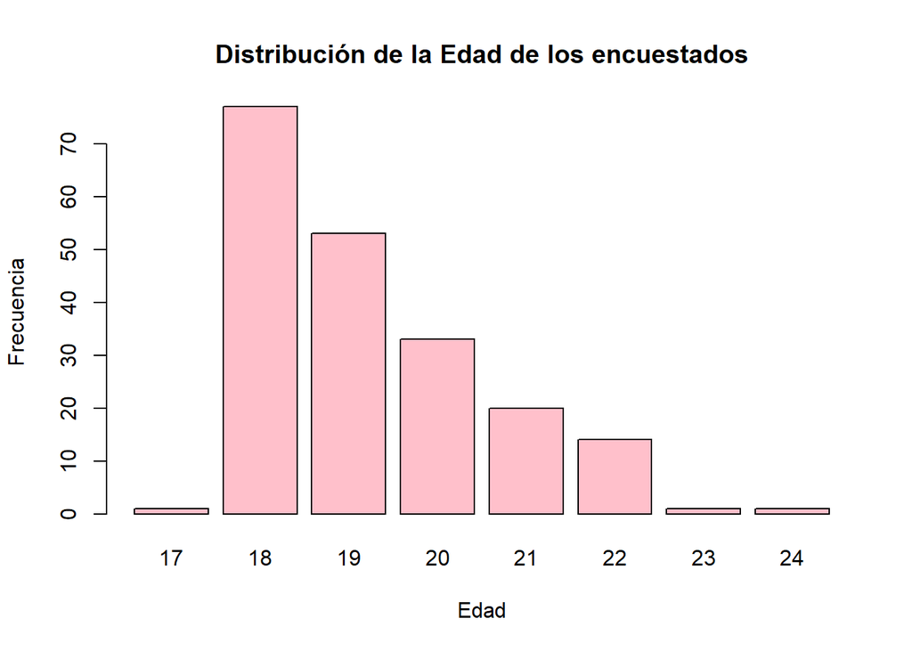

```r
tabla_edad=table(P1$Edad)
barplot(tabla_edad,col = 'pink', main = "Distribución de la Edad de los encuestados", xlab = "Edad", ylab = "Frecuencia")
```

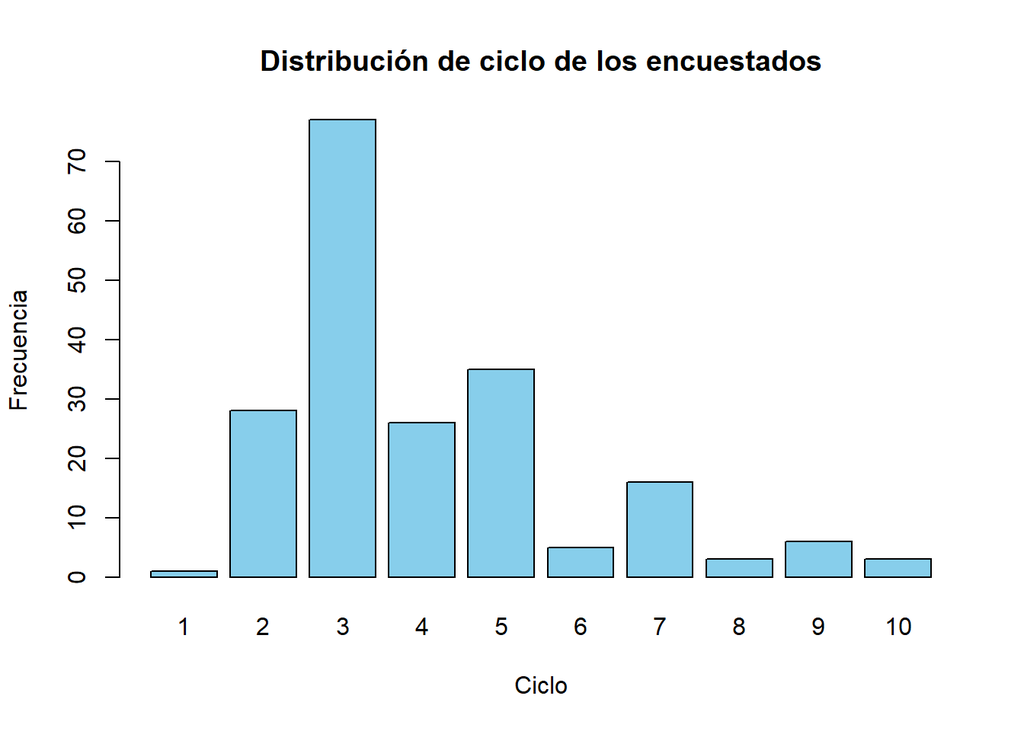

```r
tabla_ciclo=table(P1$Ciclo)
barplot(tabla_ciclo,col = 'skyblue', main = "Distribución de ciclo de los encuestados", xlab = "Ciclo", ylab = "Frecuencia")
```

En la gráfica se muestra la distribución de las personas encuestadas según el ciclo que están cursando. Se han encuestado alumnos del primer hasta el décimo ciclo Se puede observar que la gráfica tiene un sesgo hacia la derecha por la cola larga en el lado derecho, y esto se confirma debido a que la mediana es menor que la media y por ello, se puede decir que la distribución es asimétrica. Analizando la gráfica, apreciamos que hay más alumnos cursando en el 3er ciclo y la minoría se encuentra en el 1er ciclo.

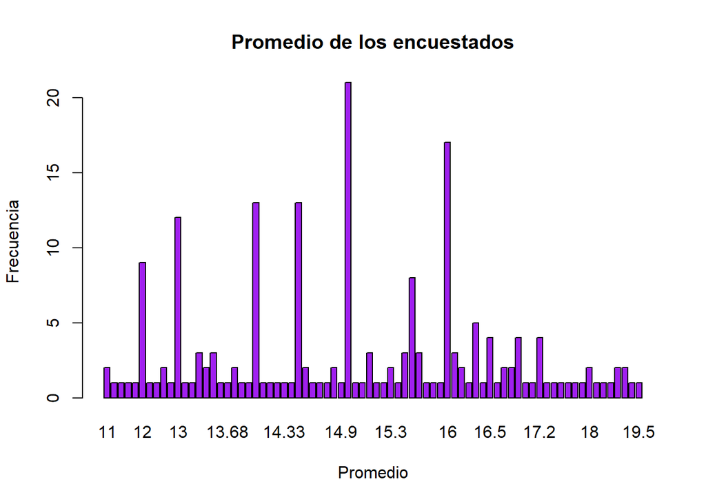

```r
tabla_promedio=table(P1$Promedio)
barplot(tabla_promedio,col = 'purple', main = "Promedio de los encuestados", xlab = "Promedio", ylab = "Frecuencia")
```

En la gráfica podemos apreciar el promedio de las notas de los alumnos de la UTEC. Esta variable es de suma importancia, ya que nos ayudará a saber qué método es el más eficiente de las múltiples opción. De está gráfica se puede interpretar que el promedio de los alumnos de UTEC más sacado es 15. Además se puede decir que es del tipo de distribución simétrica,ya que la línea vertical que pasa por su media, divide a su representación gráfica en dos partes simétricas. Ello equivale a decir que los valores equidistantes de la media, a uno u otro lado, presentan la misma frecuencia.

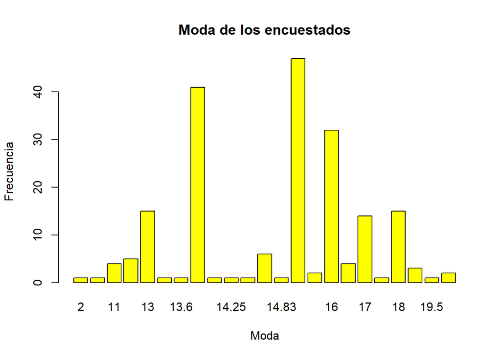

```r
tabla_moda=table(P1$Moda)
barplot(tabla_moda,col = 'yellow', main = "Moda de los encuestados", xlab = "Moda", ylab = "Frecuencia")
```

En la gráfica podemos apreciar la moda de notas en los exámenes del ciclo regular anterior de los alumnos de UTEC, donde se ve que la mayor moda de las notas es 15, al igual que el promedio de notas de la gráfica anterior.

# Diagramas de dispersión

## Diagrama de dispersión días a la semana y Tiempo

```r
cor(P1$Tiempo,P1$Dias_a_la_semana)
```

```
## [1] 0.2358302
```

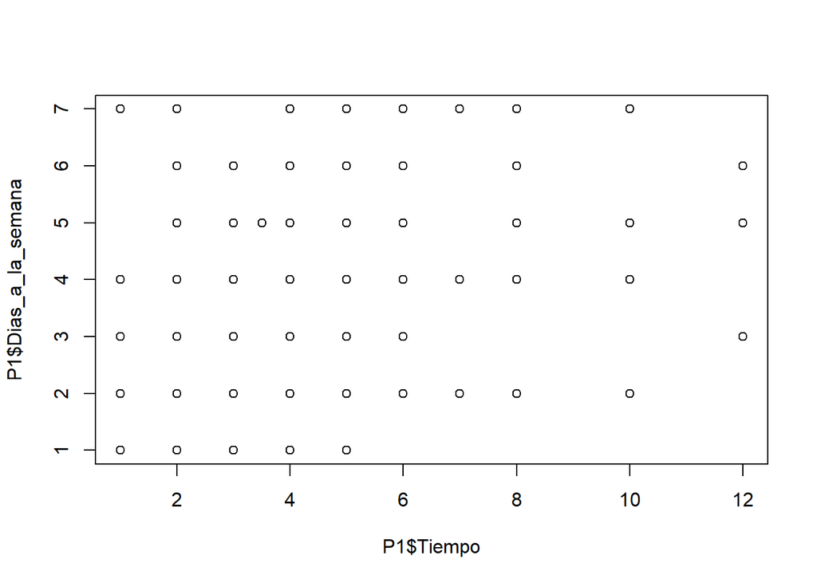

```r
plot(P1$Tiempo,P1$Dias_a_la_semana)
```

En este diagrama de dispersión de los días que estudia a la semana y Tiempo que le dedica a estudiar en horas al día, se puede apreciar que no tiene un tipo de relación entre variables, ya que van en linea recta, por lo que cada variable es independiente.

## Diagrama de dispersión días a la semana y promedio

```r
cor(P1$Dias_a_la_semana,P1$Promedio)
```

```
## [1] 0.1362575
```

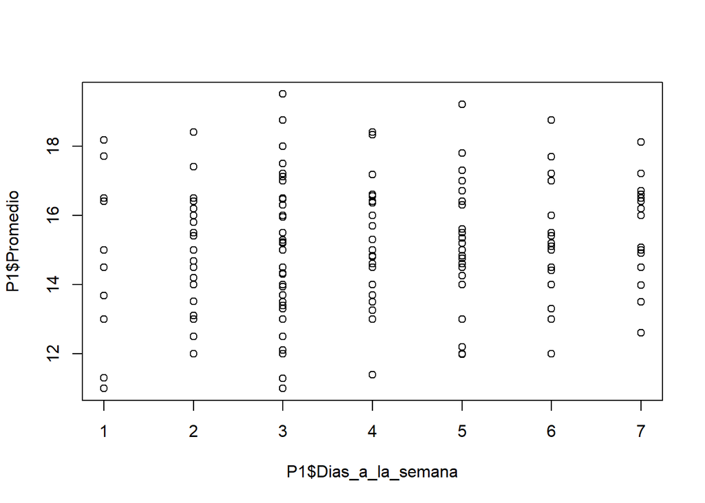

```r
plot(P1$Dias_a_la_semana,P1$Promedio)
```

## Diagrama de dispersión días de anticipación y promedio

```r
cor(P1$Dias_de_anticipacion,P1$Promedio)
```

```
## [1] 0.1740836
```

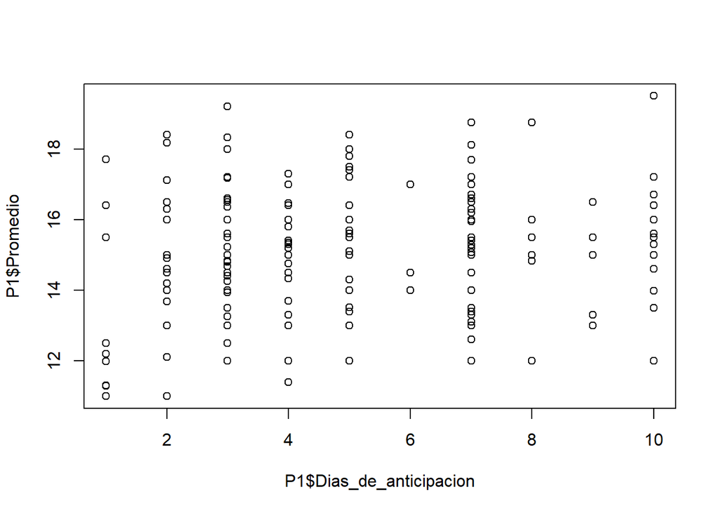

```r
plot(P1$Dias_de_anticipacion,P1$Promedio)
```

# Graficos para poder resolver los objetivos

## Gráfico de barras Género, promedio y Metodo

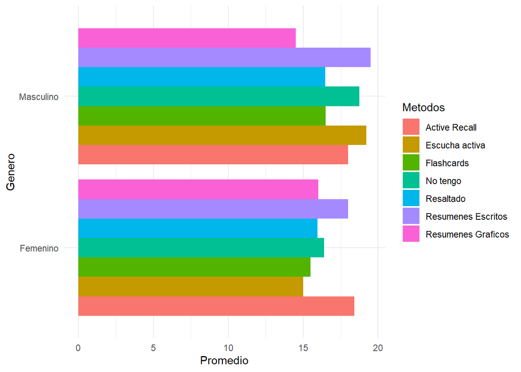

```r
ggplot(P1,aes(x=Genero, y=Promedio, fill=Metodos))+ geom_bar(position = "dodge", stat = "identity")+coord_flip()+ theme_minimal()
```

En este gráfico de barras donde se relacionan las variables Género, promedio y método se puede apreciar que a los varones con el método de resúmenes escritos les favorece con un mejor promedio de notas, y en las mujeres el Active Recall favorece en sus promedios, teniendo un sesgo a la izquierda, confirmando que la mediana el mayor a la media.